# Домашняя работа №1

Dmitrii Lokshtein

5 октября 2018 г

## Работа с данными

Загрузили данные в датафрейм при помощи read.table

```r
data.df<-read.table("http://people.math.umass.edu/~anna/Stat597AFall2016/rnf6080.dat")
```

Сколько строк и столбцов в data.df? Если получилось не 5070 наблюдений 27 переменных, то проверяйте аргументы. Строк:5070 Столбцов:27

```
##  [1] "V1"  "V2"  "V3"  "V4"  "V5"  "V6"  "V7"  "V8"  "V9"  "V10" "V11"
## [12] "V12" "V13" "V14" "V15" "V16" "V17" "V18" "V19" "V20" "V21" "V22"
## [23] "V23" "V24" "V25" "V26" "V27"
```

```
## [1] 0
```

```
##   V1 V2 V3 V4 V5 V6 V7 V8 V9 V10 V11 V12 V13 V14 V15 V16 V17 V18 V19 V20
## 2 60  4  2  0  0  0  0  0  0   0   0   0   0   0   0   0   0   0   0   0
##   V21 V22 V23 V24 V25 V26 V27
## 2   0   0   0   0   0   0   0
```

```
##   year month day 0 1 2 3 4 5 6 7 8 9 10 11 12 13 14 15 16 17 18 19 20 21
## 1   60     4   1 0 0 0 0 0 0 0 0 0 0  0  0  0  0  0  0  0  0  0  0  0  0
## 2   60     4   2 0 0 0 0 0 0 0 0 0 0  0  0  0  0  0  0  0  0  0  0  0  0
## 3   60     4   3 0 0 0 0 0 0 0 0 0 0  0  0  0  0  0  0  0  0  0  0  0  0
## 4   60     4   4 0 0 0 0 0 0 0 0 0 0  0  0  0  0  0  0  0  0  0  0  0  0
## 5   60     4   5 0 0 0 0 0 0 0 0 0 0  0  0  0  0  0  0  0  0  0  0  0  0
## 6   60     4   6 0 0 0 0 0 0 0 0 0 0  0  0  0  0  0  0  0  0  0  0  0  0
##   22 23
## 1  0  0
## 2  0  0
## 3  0  0
## 4  0  0
## 5  0  0
## 6  0  0
```

```
##      year month day 0 1 2 3 4 5 6 7 8 9 10 11 12 13 14 15 16 17 18 19 20
## 5065   80    11  25 0 0 0 0 0 0 0 0 0 0  0  0  0  0  0  0  0  0  0  0  0
## 5066   80    11  26 0 0 0 0 0 0 0 0 0 0  0  0  0  0  0  0  0  0  0  0  0
## 5067   80    11  27 0 0 0 0 0 0 0 0 0 0  0  0  0  0  0  0  0  0  0  0  0
## 5068   80    11  28 0 0 0 0 0 0 0 0 0 0  0  0  0  0  0  0  0  0  0  0  0
## 5069   80    11  29 0 0 0 0 0 0 0 0 0 0  0  0  0  0  0  0  0  0  0  0  0
## 5070   80    11  30 0 0 0 0 0 0 0 0 0 0  0  0  0  0  0  0  0  0  0  0  0
##      21 22 23
## 5065  0  0  0
## 5066  0  0  0
## 5067  0  0  0
## 5068  0  0  0
## 5069  0  0  0
## 5070  0  0  0
```

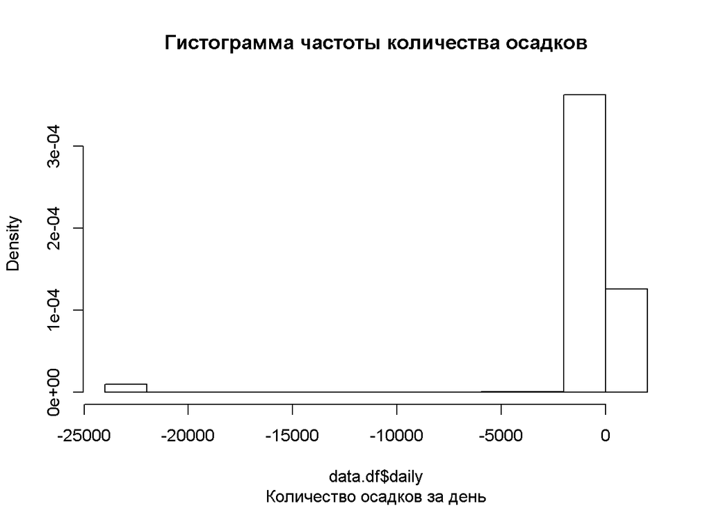

Вывод: Имеются отрицательные значения

Исправили data.df

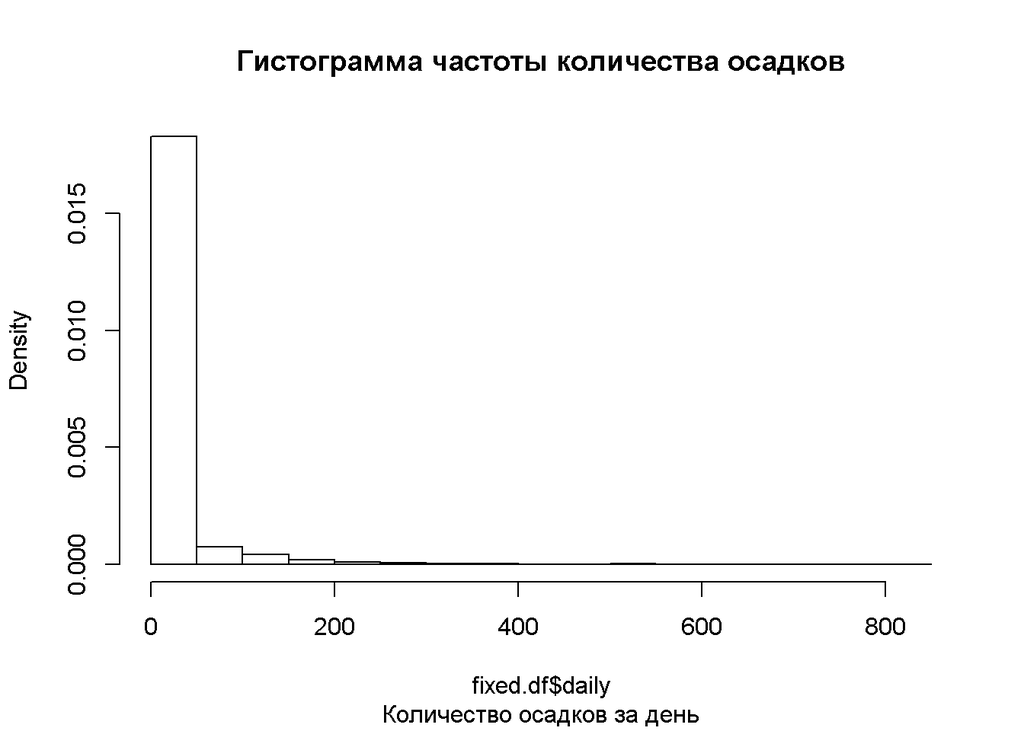

```r
fixed.df<-data.df
for (i in 1:nrow(fixed.df)){
  for (j in 1:ncol(fixed.df))
  {
    if (data.df[i,j] < 0)
    {
      data.df[i,j]<-0
    }
  }
}
names(fixed.df) <- c("year", "month", "day", seq(0,23), "daily")
fixed.df$daily<-apply(data.df[,4:27], 1, sum)

hist(fixed.df$daily, prob = TRUE, main = "Гистограмма частоты количества осадков",
     sub = "Количество осадков за день")
```

## Синтаксис и типизирование

v <- c(“4”, “8”, “15”, “16”, “23”, “42”) - создает вектор значений max(v) - ищет максимум (символ “8” элемента вектора “8” имеет максимальное значение в кодировке) sort(v) - сортирует элементы по возрастанию sum(v) - Ошибка выполнения функции, т.к. функция не может работать с типом аргумента - “символ”, вектор v состоит из символов

v2 <- c(“5”,7,12) v2[2] + 2[3] - Не может сложить числа. Ошибка: unexpected symbol in “v2[2] + 2[3] - не может”

df3 <- data.frame(z1=“5”,z2=7,z3=12) df3[1,2] + df3[1,3] - складывает 2 и 3 элемент датафрейма

l4 <- list(z1=“6”, z2=42, z3=“49”, z4=126) l4[[2]] + l4[[4]] - склдадывает значения элементов 2 и 4 компонентов списка l4[2] + l4[4] - Не может сложить z2 и z4 компоненты списка Ошибка: Error in l4[2] + l4[4] : non-numeric argument to binary operator

## Работа с функциями и операторами

1.Оператор двоеточие создаёт последовательность целых чисел по порядку. Этот оператор — частный случай функции seq(), которую вы использовали раньше. Изучите эту функцию, вызвав команду ?seq. Испольуя полученные знания выведите на экран

1. Числа от 1 до 10000 с инкрементом 372. 1, 373, 745, 1117, 1489, 1861, 2233, 2605, 2977, 3349, 3721, 4093, 4465, 4837, 5209, 5581, 5953, 6325, 6697, 7069, 7441, 7813, 8185, 8557, 8929, 9301, 9673
2. Числа от 1 до 10000 длиной 50. 1, 205.0612245, 409.122449, 613.1836735, 817.244898, 1021.3061224, 1225.3673469, 1429.4285714, 1633.4897959, 1837.5510204, 2041.6122449, 2245.6734694, 2449.7346939, 2653.7959184, 2857.8571429, 3061.9183673, 3265.9795918, 3470.0408163, 3674.1020408, 3878.1632653, 4082.2244898, 4286.2857143, 4490.3469388, 4694.4081633, 4898.4693878, 5102.5306122, 5306.5918367, 5510.6530612, 5714.7142857, 5918.7755102, 6122.8367347, 6326.8979592, 6530.9591837, 6735.0204082, 6939.0816327, 7143.1428571, 7347.2040816, 7551.2653061, 7755.3265306, 7959.3877551, 8163.4489796, 8367.5102041, 8571.5714286, 8775.6326531, 8979.6938776, 9183.755102, 9387.8163265, 9591.877551, 9795.9387755, 10^{4}

2.Функция rep() повторяет переданный вектор указанное число раз. Объясните разницу между rep(1:5,times=3) и rep(1:5, each=3)

```r
rep(1:5,times=3)
```

```
##  [1] 1 2 3 4 5 1 2 3 4 5 1 2 3 4 5
```

```r
rep(1:5, each=3)
```

```
##  [1] 1 1 1 2 2 2 3 3 3 4 4 4 5 5 5
```

Ответ: В первом случае дублируется весь вектор. Во втором каждое число